# AC Circuits

Earlier we discussed notation from IEEE and MKS and mentioned that In this book, we use MKS units and IEEE standards as far as possible. Some textbook use different notation.

###### Notation in the textbook Power Systems Analysis by Grainger and Stevenson

[figure not shown]

The phasor representations of sinusoidal voltages and currents uses notation of capital letters V and I to indicate phasors (using appropriate subscripts where necessary). To indicate the magnitude of these phasors, Grainger ad Stevenson use V and I enclosed by vertical bars (|V| and |I|).

Where a generated voltage, that is, an electromotive force (EMF), is specified, the letter E rather than V is often used for voltage to emphasize the fact that an EMF, rather than a general potential difference between two points, is being considered.

$$ V = |V|\angle \alpha \quad \text{and}\quad I = |I|\angle \beta \quad\text{and}\quad Z = |Z|\angle \theta$$

## Complex numbers

A complex number may be represented in rectangular (Cartesian) or polar form (magnitude-angle). These representations are mathematically equivalent and can be converted using already mentioned Euler's identity $e^{j\theta} = cos\theta+jsin\theta$

The impedance $Z = |Z|\angle \theta$, has a modulus and argument Z = R + jX,

Complex Number: Z = R + jX

Modulus (magnitude): $|Z| = \sqrt{R^2 + X^2}$

Argument: $\theta = tan^{-1}\bigg(\frac{X}{R}\bigg)$

Python Code:

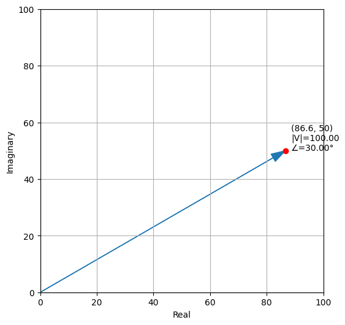

```
Magnitude = 100.00
Phase angle = 30.00°
```

If the terminals of the loads are named *a* and *n*, and voltage and current are expressed as:

$$v_{an} = V_{\max}\cos(\omega t) \qquad i_{an} = I_{\max}\cos(\omega t - \theta)$$

Then the instantaneous power is:

$$p = v_{an}i_{an} = V_{\max}I_{\max}\cos(\omega t)\cos(\omega t - \theta)$$

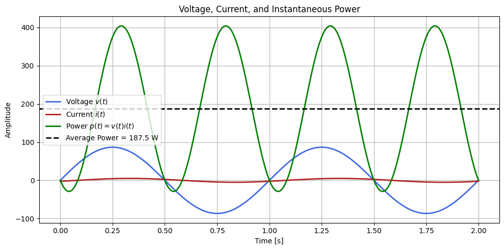

```
Average Power = 187.49 W
```

[figure not shown]

## Complex Power

Calculation of real and reactive by using complex form, we use complex conjugate, $Z^*$, because multiplying a complex number by its conjugate gives

\begin{equation} zz^*=(a+jb)(a-jb)=a^2+b^2=|z|^2 \end{equation}

$$ VI^{*} = |V|e^{j\alpha}\times|I|e^{-j\beta} = |V||I|e^{j(\alpha-\beta)} = |V||I|\angle(\alpha-\beta) $$

$$ S = VI^{*} = |V||I|\cos(\alpha-\beta) + j|V||I|\sin(\alpha-\beta) $$

$$ S = P + jQ $$

where

$$ P = |V||I|\cos(\alpha-\beta) $$

and

$$ Q = |V||I|\sin(\alpha-\beta). $$

## Power triangle

The power triangle depict the relation of $\frac{P}{|S|}$ by the cosine to the angle between them, $\theta$.

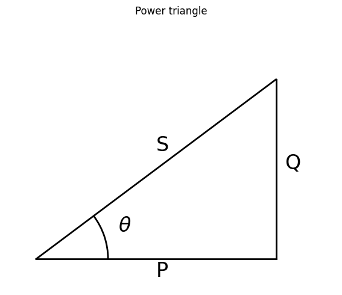

### EXAMPLE 2.1

A 50-kW inductive load is operated at a lagging power factor of 0.8. The supply voltage is 220 V at 60 Hz. Determine the size of the required parallel capacitor to improve the overall power factor to 0.95 lagging.

$P = 50 kw$

$PF_{old} = 0.8$

$PF_{new} = 0.95$

$$ Q = P\tan(\theta). $$

$$ Q_c = P\left[\tan(\theta_1)-\tan(\theta_2)\right] $$

Knowing the size of the capacitor, $Q_c$, we know that:

$$ |Q_c| = \frac{V^2}{X_C} $$

and

$$ X_C = \frac{1}{2\pi fC} $$

rearrange

$$ C = \frac{Q_C}{2\pi fC} $$

Below in Python code:

[output not shown]

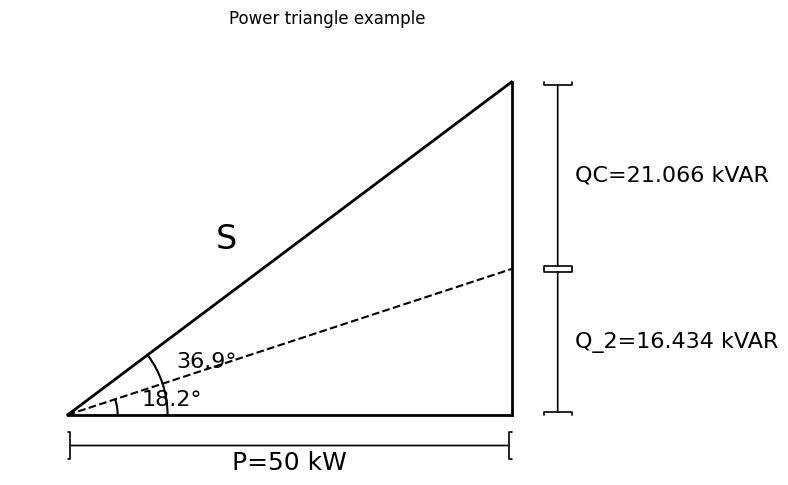

# Polyphase systems

Three-phase power became dominant because it achieves nearly all of the benefits of a multiphase system while keeping wiring, generators, transformers, motors, and transmission networks relatively simple and economical. Higher phase counts offer only incremental improvements for substantially greater complexity.

The 3-phases are displaced 120 degrees apart, and theire vectorial sum is zero:

$$1\angle0+1\angle -120+1\angle120 = 0$$

An eleoctromotive force (emf) is produced by a rotor rotating in a magnetic field.

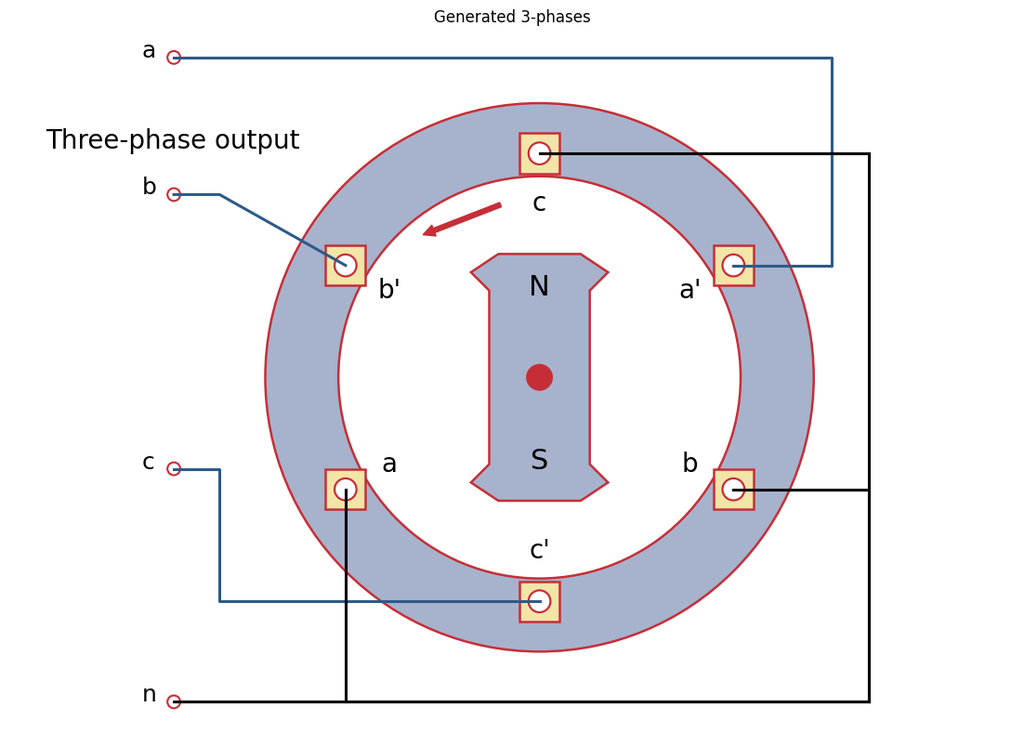

[figure not shown]

# $\alpha$-operator

$$ \alpha = e^{j\frac{2\pi}{3}} = -\frac{1}{2}+j \frac{\sqrt{3}}{2} $$

| Operator | Rectangular Form | Polar Form |
| --- | --- | --- |
| $1=\alpha^0$ | $1+j0$ | $1\angle0^\circ$ |
| $\alpha$ | $-\frac12+j\frac{\sqrt3}{2}$ | $1\angle120^\circ$ |
| $\alpha^2$ | $-\frac12-j\frac{\sqrt3}{2}$ | $1\angle240^\circ$ |
| $\alpha^3$ | $1$ | $1\angle360^\circ$ |
| $\alpha^4$ | $\alpha$ | $1\angle120^\circ$ |
| $\alpha^5$ | $\alpha^2$ | $1\angle240^\circ$ |

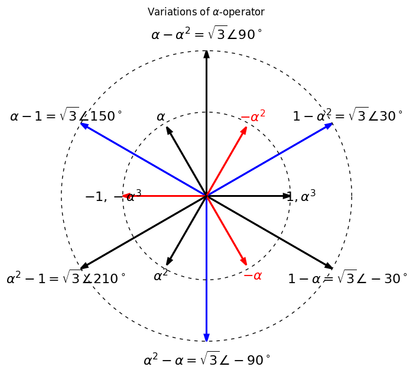

## Line - to - line voltage operators

| Expression | Simplified Form | Polar Form |
| --- | --- | --- |
| $1-\alpha$ | $\sqrt3\,\angle(-30^\circ)$ | $\sqrt3 e^{-j30^\circ}$ |
| $1-\alpha^2$ | $\sqrt3\,\angle(30^\circ)$ | $\sqrt3 e^{j30^\circ}$ |
| $\alpha-\alpha^2$ | $\sqrt3\,\angle(90^\circ)$ | $\sqrt3 e^{j90^\circ}$ |
| $\alpha-1$ | $\sqrt3\,\angle(150^\circ)$ | $\sqrt3 e^{j150^\circ}$ |
| $\alpha^2-1$ | $\sqrt3\,\angle(-150^\circ)$ | $\sqrt3 e^{-j150^\circ}$ |
| $\alpha^2-\alpha$ | $\sqrt3\,\angle(-90^\circ)$ | $\sqrt3 e^{-j90^\circ}$ |

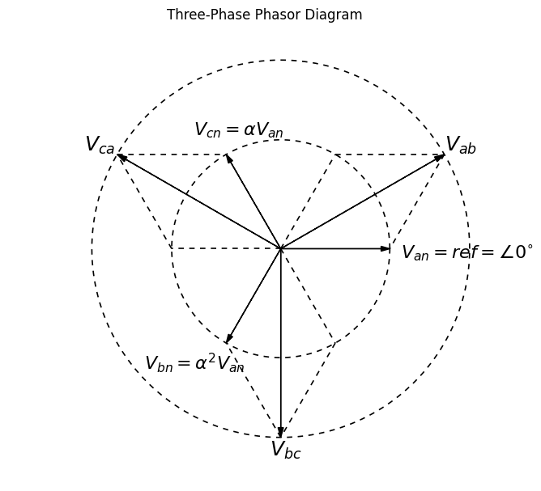

### EXAMPLE 2.3

In a balanced three-phase circuit, the voltage Vab is $173.2\angle 0^{\circ}$ V. Determine all the voltages and the currents in a Y-connected load having $Z_L= 10\angle 20^{\circ}\Omega$. Assume that the phase sequence is *abc*.

Balanced Three-Phase Y-Connected Load Solution

Given: Vab = 173.2∠0° V ZL = 10∠20° Ω Phase sequence = abc

Phase Voltages: Van = 100∠-30° V Vbn = 100∠-150° V Vcn = 100∠90° V

Line Voltages: Vab = 173.2∠0° V Vbc = 173.2∠-120° V Vca = 173.2∠120° V

Phase/Line Currents: Ia = Ian = 10∠-50° A Ib = Ibn = 10∠-170° A Ic = Icn = 10∠70° A

Python Script:

|  | Van | Vbn | Vcn | Vab | Vbc | Vca | Ian | Ibn | Icn |
| --- | --- | --- | --- | --- | --- | --- | --- | --- | --- |
| Magnitude | 100.0 | 100.0 | 100.0 | 173.2 | 173.2 | 173.2 | 10.0 | 10.0 | 10.0 |
| Angle (°) | -30.0 | -150.0 | 90.0 | 0.0 | -120.0 | 120.0 | -50.0 | -170.0 | 70.0 |
| Unit | V | V | V | V | V | V | A | A | A |

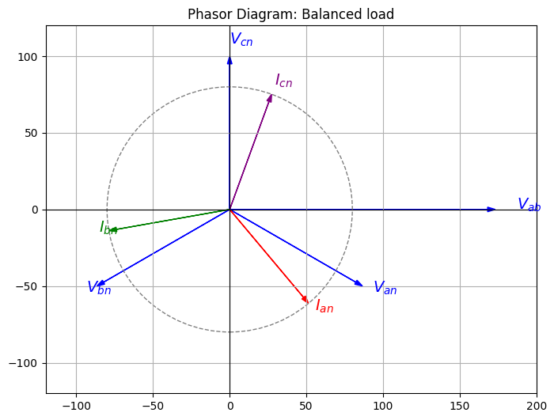

## Control

Checking the sum of balanced systems

```python
print('Sum of line-to-neutral voltages',np.round(Van + Vbn + Vcn))
print('Sum of line-to-line voltages',np.round(Vab + Vbc + Vca))
print('Sum of line currents',np.round(Ian + Ibn + Icn))
```

```
Sum of line-to-neutral voltages 0j
Sum of line-to-line voltages 0j
Sum of line currents 0j
```

# Three-Phase Circuits

In three-phase circuits there is a 120 degree phase-shift of voltages

## $\theta_v$ in Three-Phase Systems

$$ \theta_v = \omega t + \phi $$

- $\omega t$ → time evolution
- $\phi$ → phase angle
- $\theta_v$ → instantaneous voltage angle

This is used to describe signals in the time domain.

## Three-Phase Voltages Using $\theta_v$

Standard balanced system:

$$ \begin{aligned} v_r(t) &= V_m \cos(\theta_v) \\ v_s(t) &= V_m \cos(\theta_v - 120^\circ) \\ v_t(t) &= V_m \cos(\theta_v - 240^\circ) \end{aligned} $$

Compact form:

$$ v_k(t) = V_m \cos(\theta_v - k \cdot 120^\circ), \quad k = 0, 1, 2 $$

Everything is governed by a single angle $\theta_v$:

- All three phases “rotate together”
- The phase shift is constant ($120^\circ$)

## Connection to Phasors (Rotating Vectors)

In phasor form, we write:

$$ \begin{aligned} V_r &= V \angle 0^\circ \\ V_s &= V \angle -120^\circ \\ V_t &= V \angle -240^\circ \end{aligned} $$

Interpretation:

- The phasors are constant
- The rotation is contained in:

$$ e^{j\omega t} $$

## Connection Between the Two

Time signal ↔ phasor:

$$ v_r(t) = \Re \{ V_r e^{j\omega t} \} $$

and

$$ \theta_v = \omega t $$

> "We describe the three-phase system using a single common angle $\theta_v$.  
> All phases are simply shifted versions of the same signal, with $120^\circ$ separation.  
> This means the entire system can be viewed as a single rotating quantity."

## Compact Representation

$$ v_{rst}(t) = V_m \begin{bmatrix} \cos(\theta_v) \\ \cos(\theta_v - 120^\circ) \\ \cos(\theta_v - 240^\circ) \end{bmatrix} $$

## Three-phase Animation

[figure not shown]

# Per phase equivalent

Laods can be connected in Y- or $\Delta$-connection. Balanced loads are often connected in $\Delta$

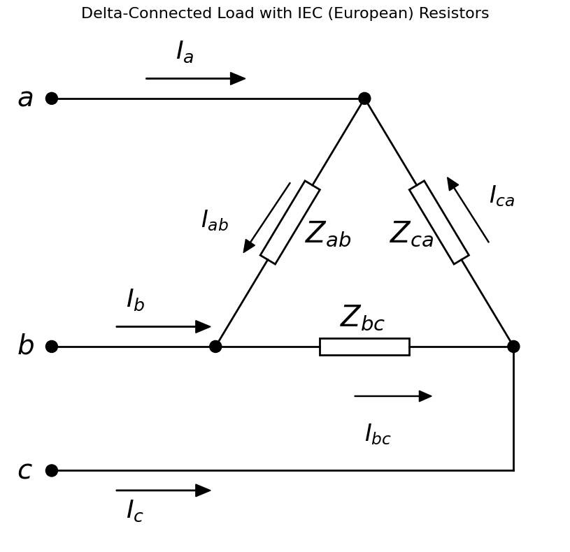

When analysing balanced 3-phase circuits it is not necessary to work with all 3 phases. We use a simplification of the 3-phases, represented with a per-phase equivalent. The per-phase equivalent consists of the voltage represented by its line-to-neutral potential, the line current, impedance (Y-connected) and a neutral connection of zero impedance. Then solve the circuit by KVL.

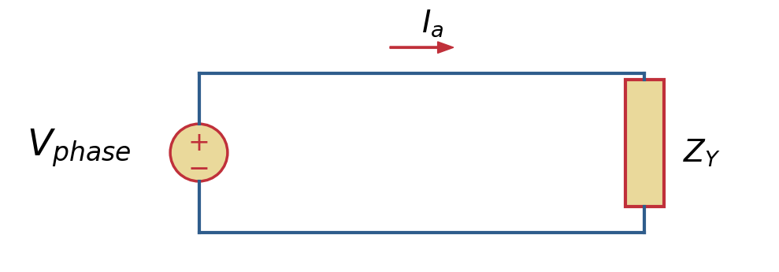

## Impedance equivalent

It is imperative that the impedance is represented by its Y-connection in a per-phase equivalent. $\Delta$- and Y-connected impedances are equivalent and can be transformed.

If we have a $\Delta$- connection it can be turned into Y-connection by:

$$Z_Y = \frac{\text{product of adjacent}Z_{\Delta}s}{\text{sum of}Z_{\Delta}} $$

If we have a Y- connection it can be turned into $\Delta$-connection by:

$$Z_{\Delta} = \frac{\text{sum of pairwaise products of}Z_{Y}s}{\text{the opposite}Z_{Y}} $$

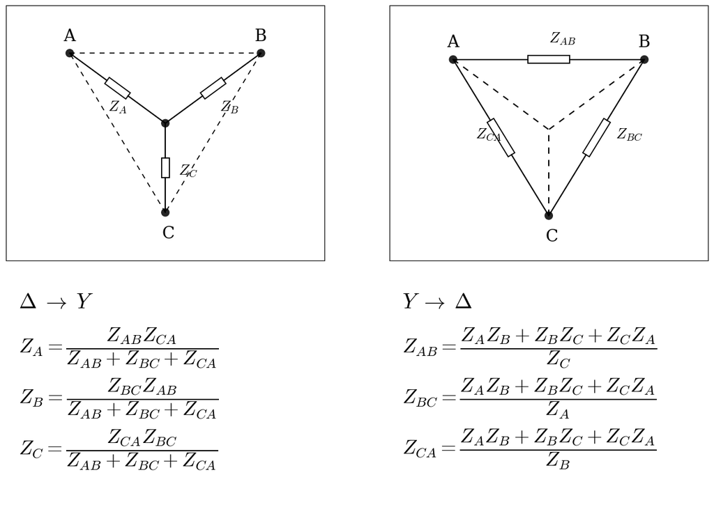

### EXAMPLE 2.4

The terminal voltage of a Y-connected load consisting of three equal impedances of $20\angle30^{\circ}\Omega$ is 4.4 kV line to line. The impedance of each of the three lines connecting the load to a bus at a substation is $Z_L = 1.4\angle75^{\circ}\Omega$.

Find the line-to-line voltage at the substation bus.

```
Load phase voltage = 2540.3 ∠0° V
Load current = 127.0 ∠-30.0° A
Line voltage drop = 177.8 ∠45.0° V
Substation phase voltage = 2669.0 ∠2.7° V
Substation line-line voltage = 4622.9 ∠32.7° V
```

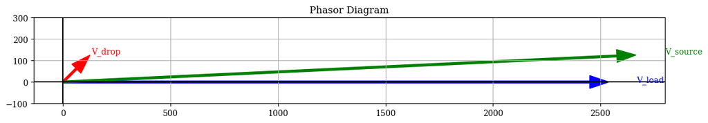

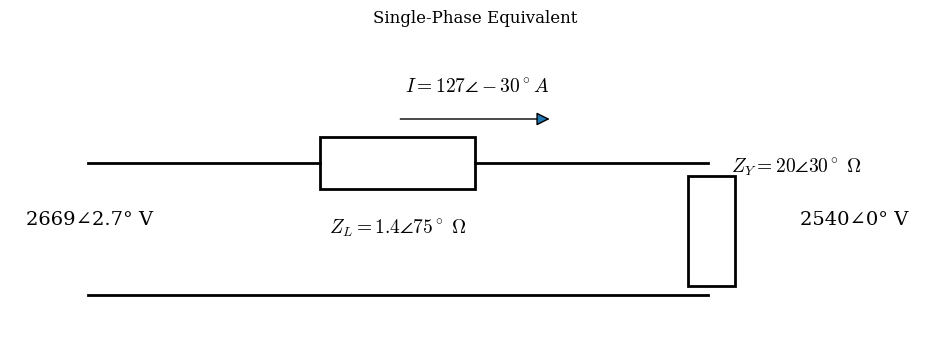

## Power in balanced 3-phase circuits

If the magnitude of the voltages to neutral (V_p) for a Y-connected load is

$$ |V_p| = |V_{an}| = |V_{bn}| = |V_{cn}| $$

and if the magnitude of the phase current (I_p) for a Y-connected load is

$$ |I_p| = |I_{an}| = |I_{bn}| = |I_{cn}| $$

the total three-phase power is

$$ P = 3|V_p||I_p|\cos\theta_p $$

where (\theta_p) is the angle by which the phase current (I_p) lags the phase voltage (V_p).

The magnitudes of line-to-line voltage (V_L) and line current (I_L) are related by

$$ |V_p| = \frac{|V_L|}{\sqrt{3}} $$

and

$$ |I_p| = |I_L| $$

Substituting into the power equation gives

$$ P = \sqrt{3}|V_L||I_L|\cos\theta_p $$

The total reactive power is

$$ Q = 3|V_p||I_p|\sin\theta_p $$

or

$$ Q = \sqrt{3}|V_L||I_L|\sin\theta_p $$

The apparent power is

$$ |S| = \sqrt{P^2 + Q^2} = \sqrt{3}|V_L||I_L| $$

For a (\Delta)-connected load,

$$ |V_p| = |V_L| $$

and

$$ |I_p| = \frac{|I_L|}{\sqrt{3}} $$

The total three-phase power is

$$ P = 3|V_p||I_p|\cos\theta_p $$

Substituting the (\Delta)-connection relationships gives

$$ P = \sqrt{3}|V_L||I_L|\cos\theta_p $$

Similarly,

$$ Q = \sqrt{3}|V_L||I_L|\sin\theta_p $$

and

$$ |S| = \sqrt{3}|V_L||I_L| $$

#### Thus, for balanced three-phase systems (whether Y-connected or (\Delta)-connected),

$$ P = \sqrt{3}|V_L||I_L|\cos\theta_p $$

$$ Q = \sqrt{3}|V_L||I_L|\sin\theta_p $$

$$ |S| = \sqrt{3}|V_L||I_L| $$

# Per unit

Per unit quantities, or pu for short, are non-dimensional units

### System Base/Power base ($S_b$)

$$ S_{\text{base}} = \text{base MVA}_{3\phi} $$

### Voltage base ($V_b$)

$$ V_{\text{base}} = {\text{base voltage, kV}_{LL}} $$

### Base Impedance

$$ Z_{base} = \frac{V_{base}^2}{S_{base}} = \frac{\text{base voltage, k}V_{LL}^2}{\text{base MVA}_{3\phi}} $$

$$ Z_{base} = \frac{V_{base_{LN}}}{I_{base}} $$

### Per-Unit Impedance

$$ \text{Per-unit impedance of an element} = \frac{\text{actual impedance, }\Omega} {\text{base impedance, }\Omega} $$

### EXAMPLE 2.6

Solve example 2.4 by using per unit. The terminal voltage of a Y-connected load consisting of three equal impedances of $20\angle30^{\circ}\Omega$ is 4.4 kV line to line. The impedance of each of the three lines connecting the load to a bus at a substation is $Z_L = 1.4\angle75^{\circ}\Omega$.

Find the line-to-line voltage at the substation bus.

```
Load phase voltage = 2540.3 ∠0° V
Load current = 127.0 ∠-30.0° A
Line voltage drop = 177.8 ∠45.0° V
Substation phase voltage = 2669.0 ∠2.7° V
Substation line-line voltage = 4622.9 ∠32.7° V
```

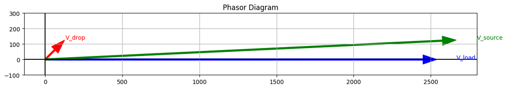

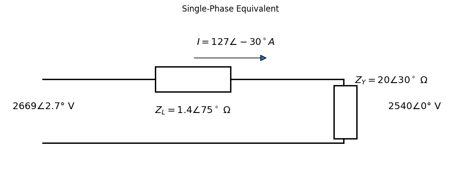

```
Zbase = (4400/sqrt(3))/127 = 20.0027 Ω
Base impedance is 20.0 Ω
Z = ZL_cp/Zbase = 0.0700 ∠ 75.00° per unit
The line impedance is 0.0700 ∠ 75.00° per unit
Ian_pu = Ian/Ibase = 1.00 ∠ -30.00° per unit
Van = 1 + Ian_pu*Z = 1.0507 ∠ 2.70° per unit
The line-to-neutral voltage at the substation Van is 1.0507 per unit with angle 2.70°
VLN = |Van| * Vbase/sqrt(3) = 2669.05 V
The magnitude of line-to-neutral voltage at the substation bus is 2669.05 V
VLL = |Van| * Vbase = 4622.92 V
The magnitude of line-to-line voltage at the substation bus is 4622.92 V
```

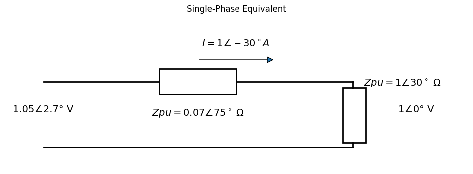

## Changing the Base of Per-Unit Quantities

To change from per-unit impedance on a given base to per-unit impedance on a new base, the following equation applies:

$$ Z_{pu_{new}} = Z_{pu_{given}} \bigg(\frac{base kV_{given}}{base kV_{new}}\bigg)^2 \bigg(\frac{base MVA_{new}}{base MVA_{given}}\bigg) $$

Per-Unit Reactance Base Conversion

The reactance of a generator designated X″ is given as 0.25 per unit based on the generator’s nameplate rating of 18 kV, 500 MVA. The base for calculations is 20 kV, 100 MVA. Find X″ on the new base.

Given: X_old = 0.25 p.u.

```
S_old = 500 MVA

V_old = 18 kV

S_new = 100 MVA

V_new = 20 kV
```

Formula: X_new = X_old * (V_old / V_new)^2 * (S_new / S_old) $$ X_{pu_{new}} = X_{pu_{given}} \bigg(\frac{V_{given}}{V_{new}}\bigg)^2 \bigg(\frac{S_{new}}{S_{given}}\bigg) $$ Calculation: X_new = 0.25* (18 / 20)^2 * (100 / 500)

```
X_new = 0.25 * 0.2 * 0.81

X_new = 0.0405 p.u.
```

Answer: X'' on the new base (20 kV, 100 MVA) = 0.0405 p.u.

Python Code:

```python
X_old = 0.25
S_old = 500.0
V_old = 18.0

S_new = 100.0
V_new = 20.0

X_new = X_old  * (V_old / V_new)**2 * (S_new / S_old)

print(f"New reactance = {X_new:.4f} p.u.")
```

```
New reactance = 0.0405 p.u.
```

# One-Line Diagram

When a 3-phase system is solved using per-phase equivalent, it can be further simplified by omitting the completed circuit through the neutral and by indicating the component parts by standard symbols rather than by their equivalent circuits. The American National Standards Institute (ANSI) and the Institute of Electrical and Electronics Engineers (IEEE) have published a set of standard symbols for electrical diagrams. Not all authors follow these symbols consistently, especially in indicating transformers, below are a few commonly used symbols:

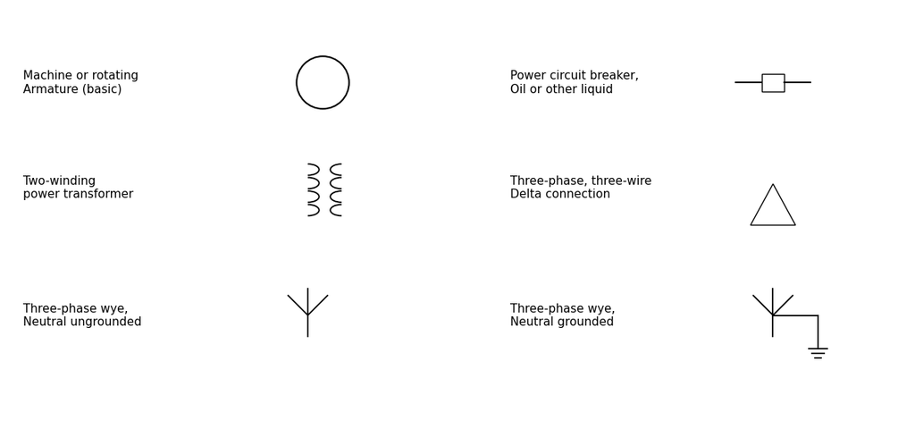

## Example of one-line diagram

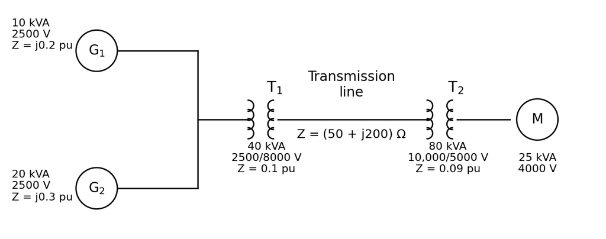

## Impedance Diagram

The per-Phase Impedance Diagram Corresponding to the Single-Line Diagram

```
Per-unit quantities
G1 = j1.000 pu
G2 = j0.750 pu
T1 = j0.125 pu
Line = 0.039 + j0.156 pu
T2 = j0.088 pu
M  = j0.500 pu
```

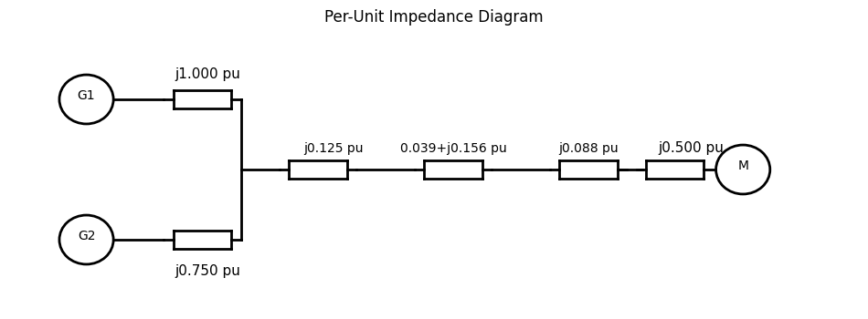